# CM20260312_process_data_Omar_hopping_2reps

2026-03-12

#Experiment We induced hopping (transposition) in three clonal cell lines from Omar with the nested SB-in-PB. This experiment (E2902) contains SB hopping from the clones in two biological replicates (2xWT78, 2xWT79, 2xWT83) and mapping of the original PB integrations.

This script also contains: - integrations site motifs (Figure 4)

In different scripts: - correlation of integrations with contact - correlation of transposition efficiency with chromatin

# Setup

##Libraries Load the libraries and set the parameters.

```r
# Load dependencies
library(GenomicRanges)
library(rtracklayer)
library(gtools)
library(tidyverse)
```

```r
library(dplyr)
library(ggplot2)
library(ggh4x)
library(stringr)
library(readr)
library(knitr)
library(cowplot)
library(ggpubr)
library(BSgenome.Mmusculus.UCSC.mm10)
library(Biostrings)
library(ggseqlogo)
library(ShortRead)
library(GENOVA)
library(GGally)
library(ggbeeswarm)
library(scales)
split_string <- function(vect,sep,N1,N2=N1){
  library(stringr)
  sapply(vect, function(X){
    paste(str_split(X,sep)[[1]][N1:N2],collapse = sep)
  },USE.NAMES = F)
}
```

## Paths & parameters

```r
#datatag
datetag = paste0("CM",format(Sys.time(), '%Y%m%d'))

# Prepare output
output_dir <- paste0("/home/c.moene/projects/hopping_technology/02_Omar_clone_pools/analysis_",datetag)
dir.create(output_dir, showWarnings = FALSE)
```

```r
library(knitr)
opts_chunk$set(cache = F,
               message = F, warning = F,
               dev=c('png', 'pdf'),
               dpi = 300,
               fig.path = paste0(file.path(output_dir), "/"))
pdf.options(useDingbats = FALSE)
```

```r
#cutoff to call an integration local
distance_local_hop = 2E6
```

# Load SB hopped clones

## PB clone and SB hopped pools

```r
MappingDataDir_E2902_SB <- "/DATA/usr/c.moene/projects/Hopping_technology/E2913_mapping_integrations_E1845_E2866_E2902_and_others/pipeline_results/mm10/home/insertions/"

# List all files
metadata_E2902 <- tibble(file = dir(MappingDataDir_E2902_SB,
                   recursive = T, full.names = T)) %>%
  # filter(grepl("insertions_ref", file)) %>%
  mutate(sample = str_remove(basename(file), "\\..*"))


metadata_E2902_Omar = metadata_E2902 %>%
  filter(grepl("E2902", sample)) %>%
  #only take the PB clone and SB pool
  filter(!grepl("_[1,2]_PB", sample))

# Load all files
tib_ints_E2902_Omar <- bind_rows(lapply(1:nrow(metadata_E2902_Omar),
                        function(i) {
                          tmp <- read_tsv(metadata_E2902_Omar$file[i],
                                          col_types = cols(
                                            .default = col_character(),
                                            start = col_double(),
                                            end = col_double(),
                                            # gap_concordance = col_double(),
                                            read_count = col_double(),
                                            mapq = col_double(),
                                            read_count_1 = col_double(),
                                            mapq_1 = col_character(),
                                            read_count_2 = col_double(),
                                            mapq_2 = col_character(),
                                            # sump = col_double(),
                                            # p_adj = col_double()
                                          )) %>%
                            mutate(sample = metadata_E2902_Omar$sample[i])
                        }))

tib_ints_E2902_Omar_annot = tib_ints_E2902_Omar %>%
  mutate(type = case_when(grepl("PB", sample) ~ "PB_clone",
                          .default = "SB_pool"),
         replicate = case_when(grepl("_1_", sample) ~ "rep1",
                               grepl("_2_", sample) ~ "rep2",
                               type == "PB_clone" ~ "rep1"),
         )
```

## combine and filter

```r
tib_Omar_comb = tib_ints_E2902_Omar_annot%>%
  mutate(parental_clone = str_extract(sample, "WT[0-9]*"),
         mapped_arms = case_when(read_count_1 == 0 ~ "rv_only",
                                 read_count_2 == 0 ~ "fw_only",
                                 read_count_1 > 0 & read_count_2 > 0 ~ "both_arms"),
         chr = factor(chr, levels = paste0("chr", c(1:19, "X", "Y")))) %>%
  filter(!is.na(chr)) #remove mitochondrial insertions and Tn5_plasmid insertions

tib_Omar_comb_PB_filt = tib_Omar_comb %>%
  filter(type == "PB_clone") %>%
  filter((read_count > 10 & read_count_1 > 1 & read_count_2 > 1))

tib_Omar_comb_SB_filt = tib_Omar_comb %>%
  filter(type == "SB_pool") # no readcount filtering, this mapping is not exhaustive


#cleanup env
rm(tib_Omar_comb, tib_ints_E2902_Omar_annot)
```

## PB launch site reference

Make a tibble of the PB ints as reference

```r
tib_PB_ints = tib_Omar_comb_PB_filt %>%
  dplyr::select(parental_clone, chr, start, end) %>%
  distinct() %>%
  mutate(LP_name = paste0(parental_clone, "_", chr, "_", start))

# write_tsv(tib_PB_ints, '/home/c.moene/projects/hopping_technology/02_Omar_clone_pools/rds/CM20260313_Omar_PB_ints_filtered.tsv')

tib_PB_ints= read_tsv('/home/c.moene/projects/hopping_technology/02_Omar_clone_pools/rds/CM20260313_Omar_PB_ints_filtered.tsv') %>%
  mutate(chr = factor(chr, levels = paste0("chr", c(1:19, "X", "Y"))))

tib_PB_ints %>%
  group_by(parental_clone) %>%
  summarize(n()) %>%
  kable()
```

| parental_clone | n() |
| --- | --- |
| WT78 | 19 |
| WT79 | 14 |
| WT83 | 14 |

#Data quality ## Is it reasonable to filter for 1 read

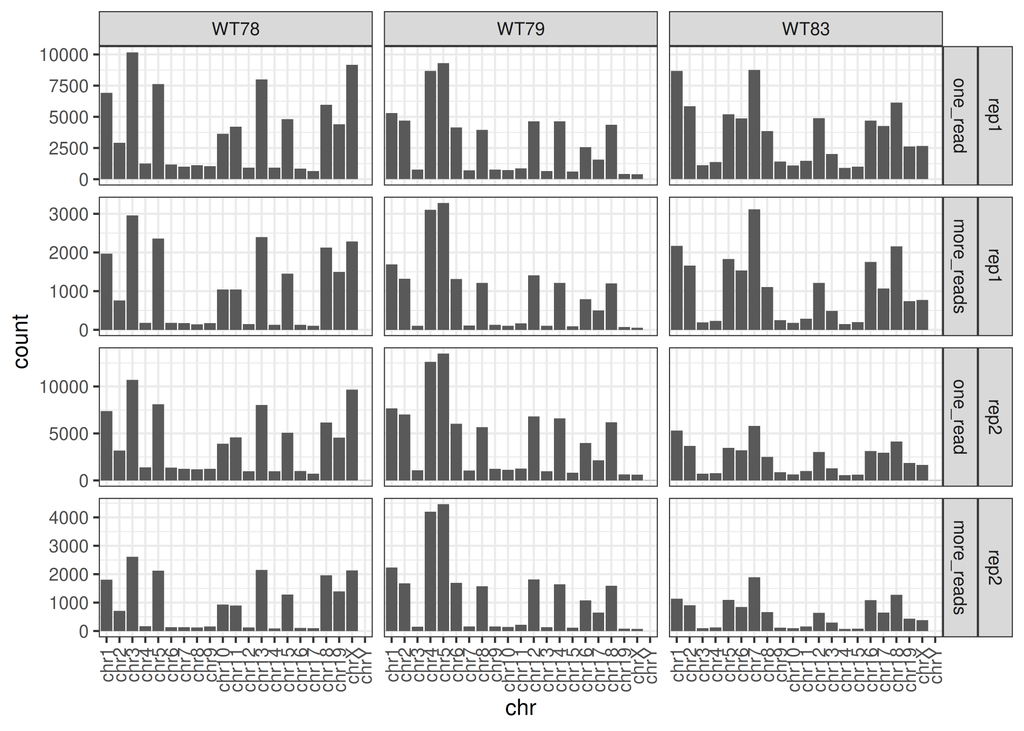

```r
# number of insertions per chr
tib_Omar_comb_SB_filt %>%
  mutate(one_read = ifelse(read_count == 1, "one_read", "more_reads")) %>%
  mutate(one_read = factor(one_read, levels = c("one_read", "more_reads"))) %>%
  ggplot(aes(x = chr)) +
  facet_grid(replicate + one_read ~ parental_clone, scales = 'free_y') +
  geom_bar() +
  theme_bw() +
  theme(axis.text.x = element_text(angle = 90, vjust = 0.5, hjust=1))
```

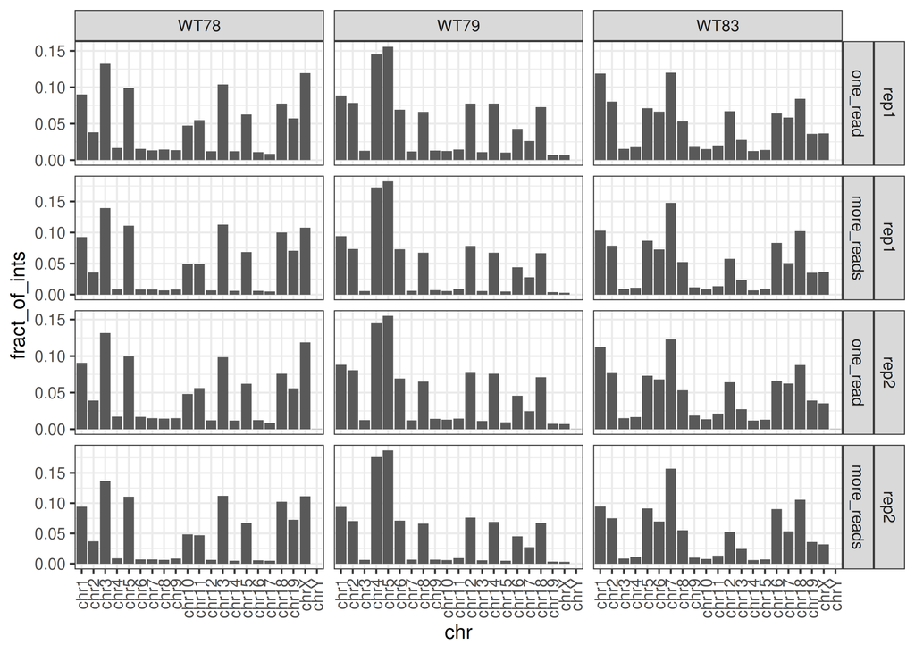

```r
#fraction of insertions per chr
tib_Omar_comb_SB_filt %>%
  mutate(one_read = ifelse(read_count == 1, "one_read", "more_reads")) %>%
  mutate(one_read = factor(one_read, levels = c("one_read", "more_reads"))) %>%
  group_by(parental_clone, replicate, one_read, chr) %>%
  summarize(N_ints = n()) %>%
  group_by(parental_clone, replicate, one_read) %>%
  mutate(fract_of_ints = N_ints/sum(N_ints)) %>%
  ggplot(aes(x = chr, y = fract_of_ints)) +
  facet_grid(replicate + one_read ~ parental_clone, scales = 'free_y') +
  geom_col() +
  theme_bw() +
  theme(axis.text.x = element_text(angle = 90, vjust = 0.5, hjust=1))
```

```r
tib_Omar_comb_SB_filt %>%
  mutate(one_read = ifelse(read_count == 1, "one_read", "more_reads")) %>%
  mutate(one_read = factor(one_read, levels = c("one_read", "more_reads"))) %>%
  group_by(parental_clone, replicate, one_read) %>%
  summarize(N_ints = n())
```

```
## # A tibble: 12 × 4
## # Groups:   parental_clone, replicate [6]
##    parental_clone replicate one_read   N_ints
##    <chr>          <chr>     <fct>       <int>
##  1 WT78           rep1      one_read    76848
##  2 WT78           rep1      more_reads  21244
##  3 WT78           rep2      one_read    81401
##  4 WT78           rep2      more_reads  19163
##  5 WT79           rep1      one_read    59857
##  6 WT79           rep1      more_reads  17979
##  7 WT79           rep2      one_read    87062
##  8 WT79           rep2      more_reads  23848
##  9 WT83           rep1      one_read    72938
## 10 WT83           rep1      more_reads  21103
## 11 WT83           rep2      one_read    47187
## 12 WT83           rep2      more_reads  12060
```

## Ideograms

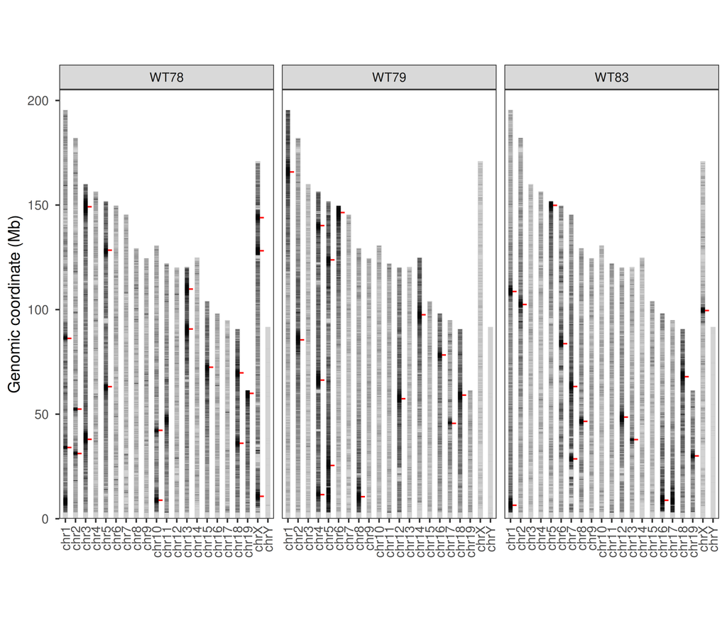

```r
chr_lengths = read_tsv('/DATA/usr/c.moene/public_data/mm10_chrom_sizes', col_names =
          c('chr', 'length')) %>%
  mutate(chr_fc = factor(chr, levels = c(paste0('chr', 1:19), 'chrX', 'chrY'))) %>%
  mutate(chr = chr_fc)

# all reps combined
ggplot(tib_Omar_comb_SB_filt,
       aes(x = as.numeric(chr) - 0.2,
           xend = as.numeric(chr) + 0.2,
           y = start, yend = start)) +
  facet_grid(. ~ parental_clone) +
  geom_col(data = chr_lengths, aes(x = chr, y=  length), fill = 'lightgrey', inherit.aes = F, width = 0.5) +
  ggrastr::rasterise(geom_segment(,
    alpha = 0.05, linewidth = 0.1
  ), dpi = 600) +
  geom_segment(data = tib_PB_ints,
               col = 'red', alpha =1,
               aes(x = as.numeric(chr) + 0.2,
                   xend = as.numeric(chr) + 0.6), linewidth = 0.5)  +
  scale_y_continuous(expand=expansion(mult = c(0, 0.05)),
                     breaks = scales::pretty_breaks(n = 4), labels = scales::unit_format(scale = 1E-6, accuracy = 1, unit=NULL)) +
  ylab('Genomic coordinate (Mb)') +
  theme_bw() +
  theme(axis.text.x = element_text(angle = 90, vjust = 0.5, hjust=1),
        legend.position = 'none',
        panel.grid = element_blank(),
         axis.title.x = element_blank(),
        aspect.ratio = 2)
```

All clones in the supplement

Only WT78 for main figure

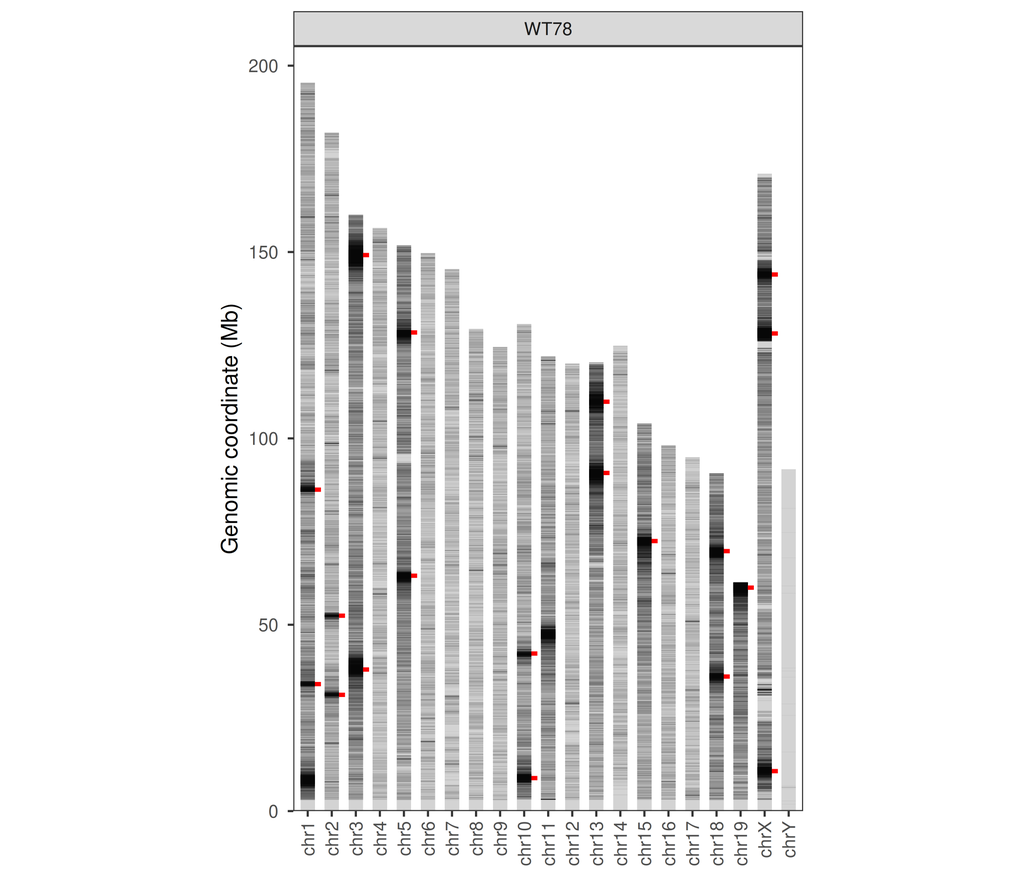

```r
chr_lengths = read_tsv('/DATA/usr/c.moene/public_data/mm10_chrom_sizes', col_names =
          c('chr', 'length')) %>%
  mutate(chr_fc = factor(chr, levels = c(paste0('chr', 1:19), 'chrX', 'chrY'))) %>%
  mutate(chr = chr_fc)

# all reps combined
ggplot(filter(tib_Omar_comb_SB_filt, parental_clone == "WT78"),
       aes(x = as.numeric(chr) - 0.3,
           xend = as.numeric(chr) + 0.3,
           y = start, yend = start)) +
  facet_grid(. ~ parental_clone) +
  geom_col(data = chr_lengths, aes(x = chr, y=  length), fill = 'lightgrey', inherit.aes = F, width = 0.6) +
  ggrastr::rasterise(geom_segment(,
    alpha = 0.05, linewidth = 0.1
  ), dpi = 600) +
  geom_segment(data = filter(tib_PB_ints, parental_clone == "WT78"),
               col = 'red', alpha =1,
               aes(x = as.numeric(chr) + 0.3,
                   xend = as.numeric(chr) + 0.55), linewidth = 1)  +
  scale_y_continuous(expand=expansion(mult = c(0, 0.05)),
                     breaks = scales::pretty_breaks(n = 4), labels = scales::unit_format(scale = 1E-6, accuracy = 1, unit=NULL)) +
  ylab('Genomic coordinate (Mb)') +
  theme_bw() +
  theme(axis.text.x = element_text(angle = 90, vjust = 0.5, hjust=1),
        legend.position = 'none',
        panel.grid = element_blank(),
         axis.title.x = element_blank(),
        aspect.ratio = 1.5)
```

### missing PB sites?

Show the 3 positions with high density SB and no mapped PB integration:

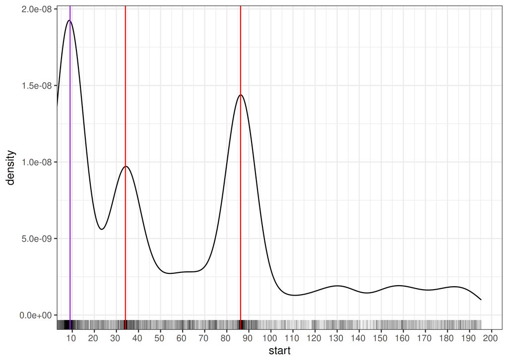

```r
ggplot(filter(tib_Omar_comb_SB_filt, parental_clone == "WT78" & chr == "chr1"),
       aes(x = start)) +
  geom_density() +
  geom_rug(alpha = 0.1, linewidth = 0.1) +
  geom_vline(data = filter(tib_PB_ints, parental_clone == "WT78"  & chr == "chr1"),
               col = 'red', alpha = 1,
               aes(xintercept = start)) +#, linewidth = 1)
  geom_vline(xintercept = 9E6, col = 'purple') +
  scale_x_continuous(expand=expansion(mult = c(0, 0.05)),
                     breaks = scales::pretty_breaks(n = 20), labels = scales::unit_format(scale = 1E-6, accuracy = 1, unit=NULL)) +
  theme_bw()
```

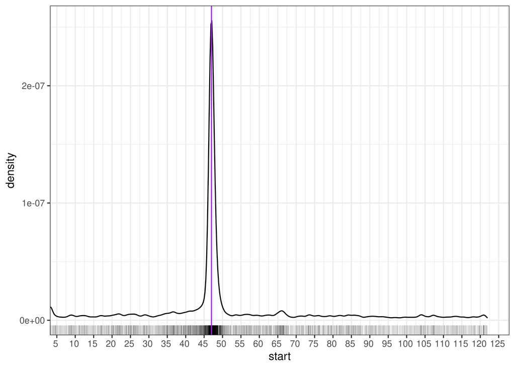

```r
ggplot(filter(tib_Omar_comb_SB_filt, parental_clone == "WT78" & chr == "chr11"),
       aes(x = start)) +
  geom_density() +
  geom_rug(alpha = 0.1, linewidth = 0.1) +
  geom_vline(data = filter(tib_PB_ints, parental_clone == "WT78"  & chr == "chr11"),
               col = 'red', alpha = 1,
               aes(xintercept = start)) +#, linewidth = 1)
  geom_vline(xintercept = 47E6, col = 'purple') +
  scale_x_continuous(expand=expansion(mult = c(0, 0.05)),
                     breaks = scales::pretty_breaks(n = 20), labels = scales::unit_format(scale = 1E-6, accuracy = 1, unit=NULL)) +
  theme_bw()
```

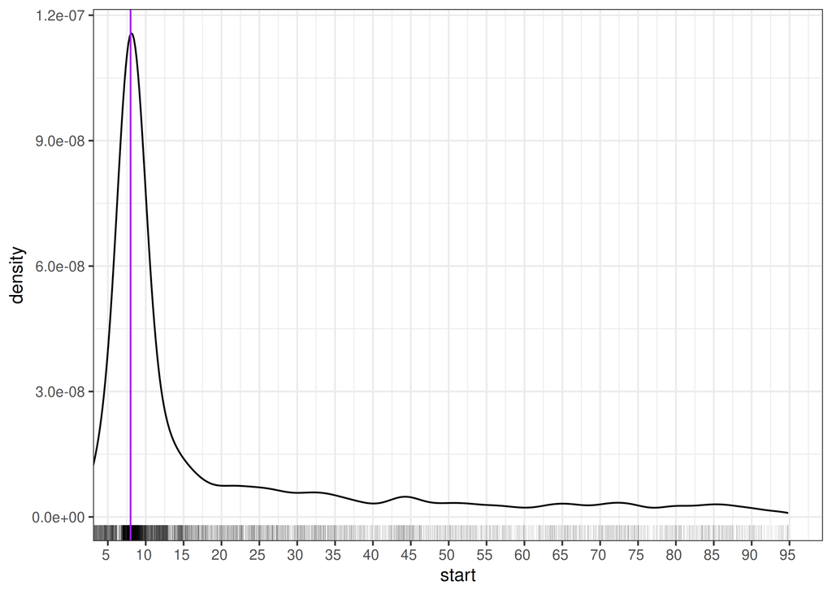

```r
ggplot(filter(tib_Omar_comb_SB_filt, parental_clone == "WT83" & chr == "chr17"),
       aes(x = start)) +
  geom_density() +
  geom_rug(alpha = 0.1, linewidth = 0.1) +
  geom_vline(data = filter(tib_PB_ints, parental_clone == "WT83" & chr == "chr17"),
               col = 'red', alpha = 1,
               aes(xintercept = start)) +#, linewidth = 1)
  geom_vline(xintercept = 8E6, col = 'purple') +
  scale_x_continuous(expand=expansion(mult = c(0, 0.05)),
                     breaks = scales::pretty_breaks(n = 20), labels = scales::unit_format(scale = 1E-6, accuracy = 1, unit=NULL)) +
  theme_bw()
```

## Example density plot

Example plot of one chromosome and how we use the 2mb region

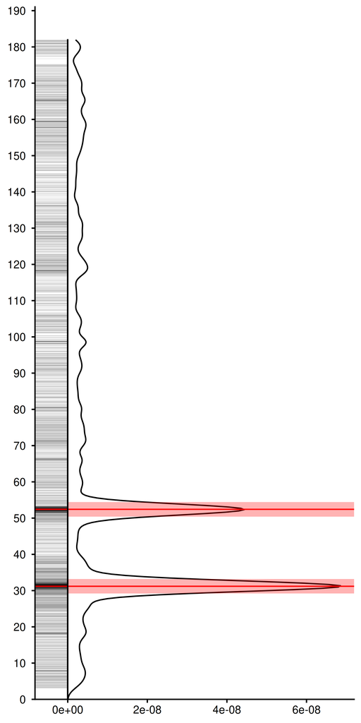

```r
ggplot(filter(tib_Omar_comb_SB_filt, parental_clone == "WT78" & chr == "chr2"),
       aes(x = start)) +
  geom_density(adjust = 0.2) +
  geom_rug(alpha = 0.1, linewidth = 0.1, length = unit(0.1, "npc"),) +
  geom_vline(data = filter(tib_PB_ints, parental_clone == "WT78"  & chr == "chr2"),
               col = 'red', alpha = 1,
               aes(xintercept = start)) +#, linewidth = 1) +
  geom_rect(data = filter(tib_PB_ints, parental_clone == "WT78"  & chr == "chr2"),
            aes(xmin = start - 2E6, ymax = start + 2E6), ymin = 0, ymax = Inf, fill = 'red', alpha = 0.3)+
  geom_segment(x = 0, xend = filter(chr_lengths, chr == "chr2")$length, y = 0,yend = 0, col = 'black') +
  # geom_vline(xintercept = 9E6, col = 'purple') +
  scale_x_continuous(expand=expansion(mult = c(0, 0.05)),
                     limits = c(0, NA),
                     breaks = scales::pretty_breaks(n = 20), labels = scales::unit_format(scale = 1E-6, accuracy = 1, unit=NULL)) +
  scale_y_continuous(expand = expansion(mult = c(0.12, 0.05)), limits = c(0, NA))+
  theme_classic() +
  coord_flip() +
  theme(axis.title.x = element_blank(),
        axis.title.y = element_blank(),
        )
```

## statistics

```r
tib_Omar_comb_SB_filt %>%
  group_by(parental_clone) %>%
  summarize(n())
```

```
## # A tibble: 3 × 2
##   parental_clone  `n()`
##   <chr>           <int>
## 1 WT78           198656
## 2 WT79           188746
## 3 WT83           153288
```

# Link SB to PB

```r
#get mouse genome seqinfo
library(BSgenome.Mmusculus.UCSC.mm10)
seqinfo_mm10 <- seqinfo(BSgenome.Mmusculus.UCSC.mm10)


parental_cell_lines = unique(tib_Omar_comb_PB_filt$parental_clone)

SB_linked_tib_ls = lapply(parental_cell_lines, function(cl){
  #make granges of the integrations
  parental_tib =  filter(tib_Omar_comb_PB_filt, parental_clone == cl & replicate == "rep1")
  parental_gr = parental_tib %>%
    GRanges(seqinfo = seqinfo_mm10)

  SB_tib = filter(tib_Omar_comb_SB_filt, parental_clone == cl) %>% dplyr::filter(!is.na(chr))
  SB_gr = SB_tib %>%
    GRanges(seqinfo = seqinfo_mm10)

  #find nearest
  nearest_idx <- GenomicRanges::nearest(SB_gr, parental_gr, ignore.strand = T)

  SB_tib_cl = SB_tib %>%
    mutate(nearest_parental_idx = nearest_idx,
           nearest_parental_start = parental_tib$start[nearest_idx],
           dist_from_PB = start - nearest_parental_start,
           abs_dist_from_PB = abs(dist_from_PB))
})

tib_PB_ints_minimal = tib_PB_ints %>% dplyr::select(-end)

SB_linked_tib = bind_rows(SB_linked_tib_ls) %>%
  left_join(tib_PB_ints_minimal, by = join_by(nearest_parental_start == start, chr == chr,  parental_clone == parental_clone))

# saveRDS(SB_linked_tib, "/home/c.moene/projects/hopping_technology/02_Omar_clone_pools/rds/CM20260330_PB_linked_filt_SB_ints_2reps.rds")
```

### local fraction

Which percentage is within 2Mb of a launch pad?

```r
fract_local_tib = SB_linked_tib %>%
  mutate(local_hop = abs_dist_from_PB < distance_local_hop & !is.na(abs_dist_from_PB)) %>%
  group_by(parental_clone, replicate) %>%
  summarize(N_local_hop = sum(local_hop),
            fract_local_hop = sum(local_hop)/length(local_hop))
summary(fract_local_tib$fract_local_hop)
```

```
##    Min. 1st Qu.  Median    Mean 3rd Qu.    Max.
##  0.4489  0.4677  0.4774  0.4730  0.4828  0.4853
```

```r
SB_linked_tib %>%
  mutate(local_hop = abs_dist_from_PB < distance_local_hop & !is.na(abs_dist_from_PB)) %>%
  # group_by(parental_clone, replicate) %>%
  summarize(N_local_hop = sum(local_hop),
            fract_local_hop = sum(local_hop)/length(local_hop))
```

```
## # A tibble: 1 × 2
##   N_local_hop fract_local_hop
##         <int>           <dbl>
## 1      255898           0.473
```

47% of integrations is within 2Mb of a LP, and this is consistent across replicates

## density around LPs

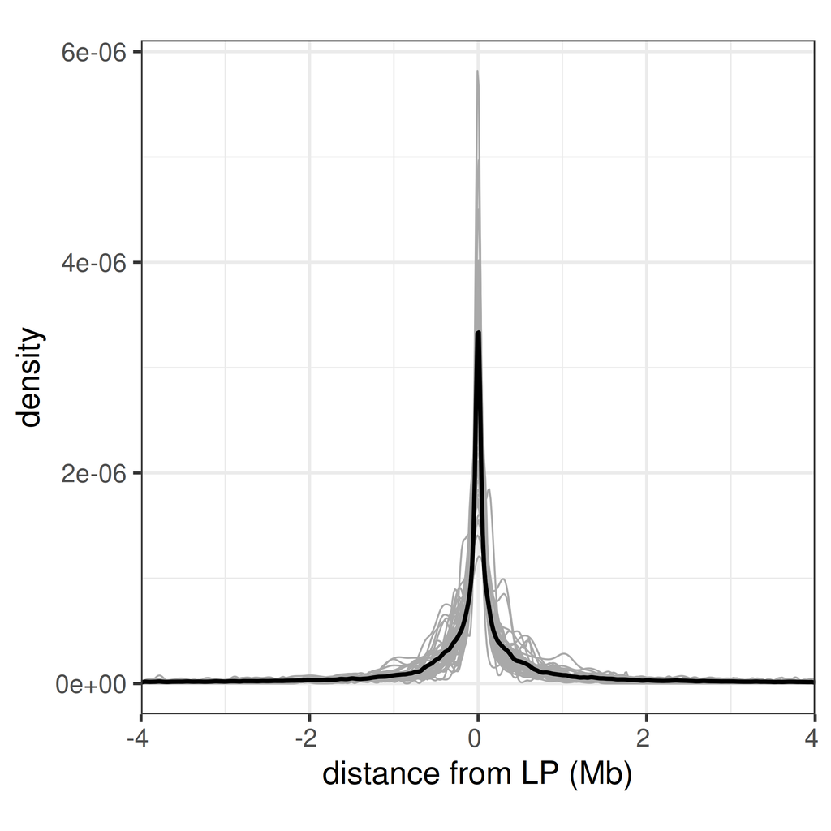

```r
ggplot(SB_linked_tib) +
  geom_density(aes(x = dist_from_PB, group = LP_name), col = 'darkgrey', linewidth = 0.3) +
  geom_density(aes(x = dist_from_PB), col = 'black', linewidth = 0.7)+
  scale_x_continuous(limits = c(-4E6, 4E6),
                     expand=c(0,0),
                     breaks = scales::pretty_breaks(n = 5), labels = scales::unit_format(scale = 1E-6, accuracy = 1, unit=NULL)) +
  xlab('distance from LP (Mb)') +
  theme_bw()  +
  theme(aspect.ratio = 1)
```

## density on other chromosomes

What is the density of integrations on other chromosomes.

Manually curate the chromosomes without any integrations (so add the three clear densities of SB integrations that suggest we missed a PB integration there).

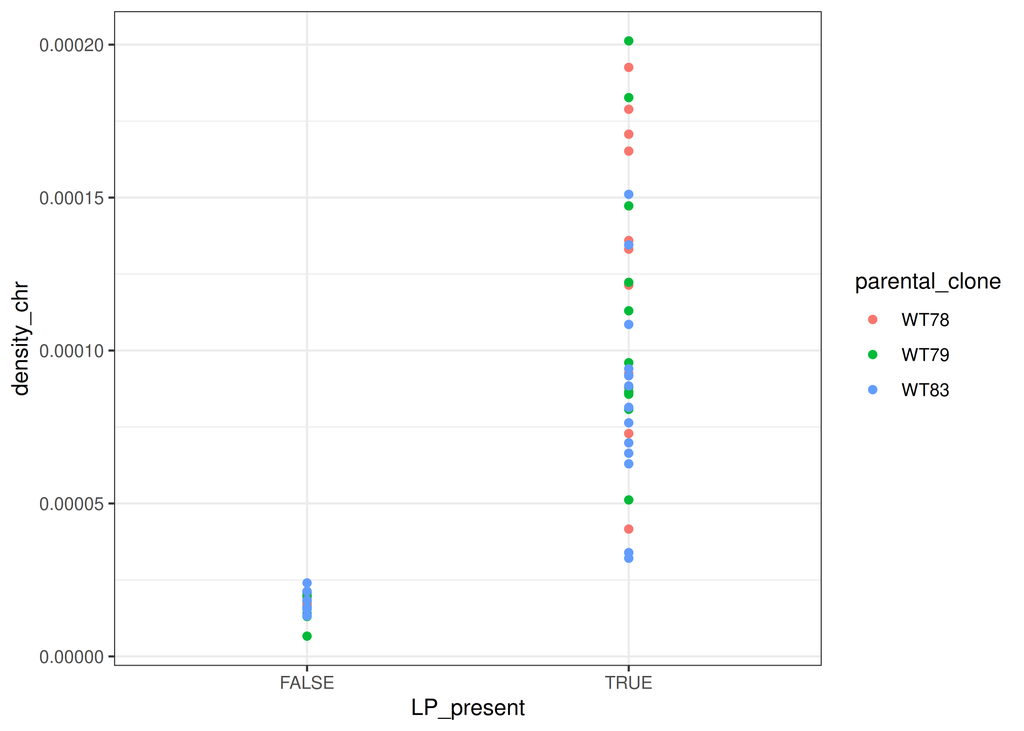

```r
visual_LPs = tibble(parental_clone = c("WT78", "WT78", "WT83"),
                    chr = c("chr1", "chr11", "chr17"))
chr_with_PB = tib_PB_ints %>%
  select(parental_clone, chr) %>%
  bind_rows(visual_LPs) %>%
  distinct() %>%
  mutate(LP_present = TRUE)

SB_ints_per_chr = SB_linked_tib %>%
  group_by(parental_clone, chr) %>%
  summarise(N_ints = n())

SB_density_per_chr = expand_grid(parental_clone = c("WT78", "WT79", "WT83"),
            chr = paste0("chr", c(1:19,"X"))) %>%
  left_join(chr_with_PB) %>%
  replace_na(list(LP_present = FALSE)) %>%
  # filter(!LP_present) %>%
  left_join(chr_lengths) %>%
  left_join(SB_ints_per_chr) %>%
  mutate(density_chr = N_ints / length )

ggplot(SB_density_per_chr, aes(x = LP_present, y=density_chr, col = parental_clone)) +
  geom_point()+
  theme_bw()
```

```r
SB_density_per_chr %>%
  group_by(parental_clone, LP_present) %>%
  summarize(total_length = sum(length),
            total_ints = sum(N_ints)) %>%
  mutate(total_density = total_ints/total_length) %>%
  mutate(ints_per_Mb = total_density * 1E6,
         ints_4Mb_region = total_density * 4E6)
```

```
## # A tibble: 6 × 7
## # Groups:   parental_clone [3]
##   parental_clone LP_present total_length total_ints total_density ints_per_Mb
##   <chr>          <lgl>             <dbl>      <int>         <dbl>       <dbl>
## 1 WT78           FALSE        1143908749      21568     0.0000189        18.9
## 2 WT78           TRUE         1489867923     177067     0.000119        119.
## 3 WT79           FALSE        1139781974      16913     0.0000148        14.8
## 4 WT79           TRUE         1493994698     171815     0.000115        115.
## 5 WT83           FALSE         922866371      15835     0.0000172        17.2
## 6 WT83           TRUE         1710910301     137434     0.0000803        80.3
## # ℹ 1 more variable: ints_4Mb_region <dbl>
```

```r
SB_density_per_chr %>%
  group_by(parental_clone, LP_present) %>%
  summarize(total_length = sum(length),
            total_ints = sum(N_ints)) %>%
  mutate(total_density = total_ints/total_length) %>%
  mutate(ints_4Mb_region = total_density * 4E6) %>%
  filter(!LP_present) %>%
  dplyr::select(parental_clone, ints_4Mb_region) %>%
  kable()
```

| parental_clone | ints_4Mb_region |
| --- | --- |
| WT78 | 75.41860 |
| WT79 | 59.35521 |
| WT83 | 68.63399 |

# Calculate hopping efficiency

Count local integrations

```r
SB_linked_tib %>%
  filter(abs_dist_from_PB <= distance_local_hop) %>%
  mutate(LP_name = paste0(parental_clone, "_", chr, "_", nearest_parental_start)) %>%
  drop_na() %>%
  group_by(replicate, parental_clone, LP_name) %>%
  summarise(count = n())
```

```
## # A tibble: 94 × 4
## # Groups:   replicate, parental_clone [6]
##    replicate parental_clone LP_name              count
##    <chr>     <chr>          <chr>                <int>
##  1 rep1      WT78           WT78_chr10_42273274    773
##  2 rep1      WT78           WT78_chr10_8855809    1797
##  3 rep1      WT78           WT78_chr13_109828239  2589
##  4 rep1      WT78           WT78_chr13_90721280   4063
##  5 rep1      WT78           WT78_chr15_72452785   3490
##  6 rep1      WT78           WT78_chr18_36095779   2652
##  7 rep1      WT78           WT78_chr18_69746533   2640
##  8 rep1      WT78           WT78_chr19_59949918   4035
##  9 rep1      WT78           WT78_chr1_34074542    1067
## 10 rep1      WT78           WT78_chr1_86237174    1727
## # ℹ 84 more rows
```

Filter for local integrations

```r
SB_ints_per_PB_rep =
  SB_linked_tib %>%
  filter(abs_dist_from_PB < distance_local_hop) %>% #only take the local hops
  group_by(replicate, parental_clone, chr, nearest_parental_idx,nearest_parental_start, ) %>%
  summarize(N_local_SB_ints = n(),
            median_dist = median(abs_dist_from_PB),
            mean_dist = mean(abs_dist_from_PB),
            N_within_10kb = sum(abs_dist_from_PB <= 10E3)) %>%
  dplyr::rename(start = nearest_parental_start) %>%
  left_join(tib_PB_ints) %>%
  #calculate number of hopped ints, relative to the mean of that parental clone
  #because pool size (number of mapped cells) as well as number of LPs differs between clones
  group_by(replicate, parental_clone) %>%
  mutate(rel_SB_ints_parental = N_local_SB_ints / mean(N_local_SB_ints))

# saveRDS(SB_ints_per_PB_rep, "/home/c.moene/projects/hopping_technology/02_Omar_clone_pools/rds/CM20260330_SB_ints_per_PB_2reps.rds")
```

## Get numbers

```r
#How many do we have in total for the replicates
kable(SB_linked_tib %>% group_by(parental_clone, replicate) %>% summarise(count = n()))
```

| parental_clone | replicate | count |
| --- | --- | --- |
| WT78 | rep1 | 98092 |
| WT78 | rep2 | 100564 |
| WT79 | rep1 | 77836 |
| WT79 | rep2 | 110910 |
| WT83 | rep1 | 94041 |
| WT83 | rep2 | 59247 |

```r
SB_linked_tib %>%
  group_by(parental_clone, replicate) %>%
  summarise(count = n()) %>%
  pivot_wider(names_from = parental_clone, values_from = count) %>%
  kable()
```

| replicate | WT78 | WT79 | WT83 |
| --- | --- | --- | --- |
| rep1 | 98092 | 77836 | 94041 |
| rep2 | 100564 | 110910 | 59247 |

```r
#How many do we have local around the LPs
kable(SB_ints_per_PB_rep %>% group_by(parental_clone, replicate) %>% summarise(count = sum(N_local_SB_ints)))
```

| parental_clone | replicate | count |
| --- | --- | --- |
| WT78 | rep1 | 47411 |
| WT78 | rep2 | 48391 |
| WT79 | rep1 | 37771 |
| WT79 | rep2 | 52521 |
| WT83 | rep1 | 42212 |
| WT83 | rep2 | 27592 |

```r
kable(SB_ints_per_PB_rep %>% group_by(parental_clone, replicate, LP_name) %>% summarise(count = sum(N_local_SB_ints)))
```

| parental_clone | replicate | LP_name | count |
| --- | --- | --- | --- |
| WT78 | rep1 | WT78_chr10_42273274 | 773 |
| WT78 | rep1 | WT78_chr10_8855809 | 1797 |
| WT78 | rep1 | WT78_chr13_109828239 | 2589 |
| WT78 | rep1 | WT78_chr13_90721280 | 4063 |
| WT78 | rep1 | WT78_chr15_72452785 | 3490 |
| WT78 | rep1 | WT78_chr18_36095779 | 2652 |
| WT78 | rep1 | WT78_chr18_69746533 | 2640 |
| WT78 | rep1 | WT78_chr19_59949918 | 4035 |
| WT78 | rep1 | WT78_chr1_34074542 | 1067 |
| WT78 | rep1 | WT78_chr1_86237174 | 1727 |
| WT78 | rep1 | WT78_chr2_31192387 | 941 |
| WT78 | rep1 | WT78_chr2_52424064 | 625 |
| WT78 | rep1 | WT78_chr3_149179806 | 3947 |
| WT78 | rep1 | WT78_chr3_37981379 | 3825 |
| WT78 | rep1 | WT78_chr5_128414294 | 2929 |
| WT78 | rep1 | WT78_chr5_63152490 | 3031 |
| WT78 | rep1 | WT78_chrX_10719384 | 2417 |
| WT78 | rep1 | WT78_chrX_128144748 | 3124 |
| WT78 | rep1 | WT78_chrX_143965783 | 1739 |
| WT78 | rep2 | WT78_chr10_42273274 | 887 |
| WT78 | rep2 | WT78_chr10_8855809 | 1849 |
| WT78 | rep2 | WT78_chr13_109828239 | 2576 |
| WT78 | rep2 | WT78_chr13_90721280 | 3959 |
| WT78 | rep2 | WT78_chr15_72452785 | 3512 |
| WT78 | rep2 | WT78_chr18_36095779 | 2682 |
| WT78 | rep2 | WT78_chr18_69746533 | 2638 |
| WT78 | rep2 | WT78_chr19_59949918 | 4093 |
| WT78 | rep2 | WT78_chr1_34074542 | 1080 |
| WT78 | rep2 | WT78_chr1_86237174 | 1882 |
| WT78 | rep2 | WT78_chr2_31192387 | 999 |

[output cut: 64 more lines]

## Correlation relative integration count

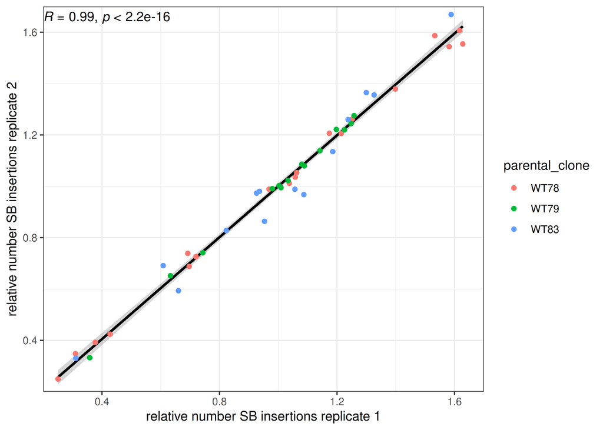

```r
#correlation relative SB integration count

SB_ints_per_PB_rep %>%
  dplyr::select(replicate, parental_clone, LP_name, rel_SB_ints_parental) %>%
  pivot_wider(names_from = replicate, values_from = rel_SB_ints_parental) %>%
  ggplot( aes(x = rep1, y = rep2)) +
  geom_smooth(method = 'lm', col = 'black') +
  geom_point(aes(col = parental_clone)) +
  scale_x_continuous(limits =c(0.2, 1.7), expand = c(0,0)) +
  scale_y_continuous(limits =c(0.2, 1.7), expand = c(0,0)) +
  labs(x = "relative number SB insertions replicate 1",
       y= "relative number SB insertions replicate 2") +
  stat_cor(method = 'pearson') +
  theme_bw()
```

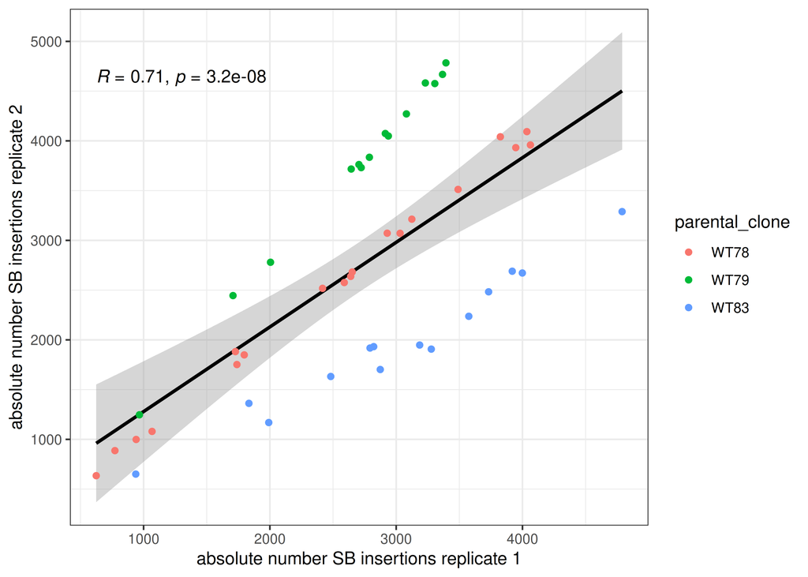

```r
#instead just correlate absolute SB counts

SB_ints_per_PB_rep %>%
  dplyr::select(replicate, parental_clone, LP_name, N_local_SB_ints) %>%
  pivot_wider(names_from = replicate, values_from = N_local_SB_ints) %>%
  ggplot( aes(x = rep1, y = rep2)) +
  geom_smooth(method = 'lm', col = 'black') +
  geom_point(aes(col = parental_clone)) +
  # scale_x_continuous(limits =c(0.2, 1.7), expand = c(0,0)) +
  # scale_y_continuous(limits =c(0.2, 1.7), expand = c(0,0)) +
  labs(x = "absolute number SB insertions replicate 1",
       y= "absolute number SB insertions replicate 2") +
  stat_cor(method = 'pearson') +
  theme_bw()
```

This demonstrates why we need to normalize within the group to be able to compare between the groups

## Distribution of hop efficiencies

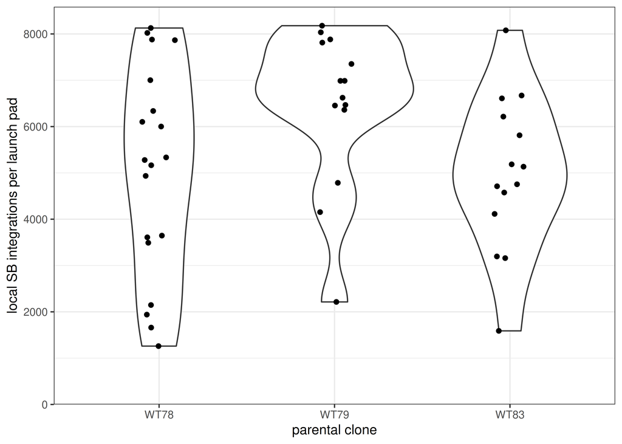

```r
#or the total
SB_ints_per_PB_rep %>%
  group_by(parental_clone, LP_name) %>%
  summarize(total_ints = sum(N_local_SB_ints)) %>%
  ggplot(aes(x = parental_clone, y = total_ints)) +
  geom_violin() +
  geom_jitter(width = 0.1, height = 0) +
  scale_y_continuous(limits = c(0, NA), expand=expansion(mult = c(0, 0.05))) +
  ylab('local SB integrations per launch pad' )+
  xlab('parental clone')+
  theme_bw()
```

```r
# get the numbers
SB_ints_per_PB_rep %>%
  group_by(parental_clone, LP_name) %>%
  summarize(total_ints = sum(N_local_SB_ints)) %>%
  summarize(min_ints = min(total_ints),
            max_ints = max(total_ints)) %>%
  mutate(fold_min_max = max_ints / min_ints) %>%
  kable()
```

| parental_clone | min_ints | max_ints | fold_min_max |
| --- | --- | --- | --- |
| WT78 | 1260 | 8128 | 6.450794 |
| WT79 | 2214 | 8178 | 3.693767 |
| WT83 | 1589 | 8078 | 5.083700 |

# Motif insertion sites

For Figure 4A: what is the sequence motif of the SB integrations?

WHY does number of integrations change?

```r
library(ggseqlogo)
#get GRanges of integrations
integration_coordinates_gr = SB_linked_tib %>%
  filter(strand != "*") %>%
  select(chr, start, strand) %>%
  mutate(end = start + 1) %>%
  GRanges()

surrounding_ints_gr =  resize(integration_coordinates_gr, 14, fix = 'center')

Biostrings::getSeq(BSgenome.Mmusculus.UCSC.mm10, surrounding_ints_gr[1:10])
```

```
## DNAStringSet object of length 10:
##      width seq
##  [1]    14 CTGATATACCTATA
##  [2]    14 TACACATATAAGAC
##  [3]    14 ACTATATATTACAA
##  [4]    14 TGTATGTATGATGT
##  [5]    14 CCCTACTATCTCCT
##  [6]    14 TTATTTTAGTTGTA
##  [7]    14 GCTACTTAGCATCA
##  [8]    14 TACACACAGTGGCC
##  [9]    14 ACTAACTAGCTTTG
## [10]    14 GGCATGTATGAACC
```

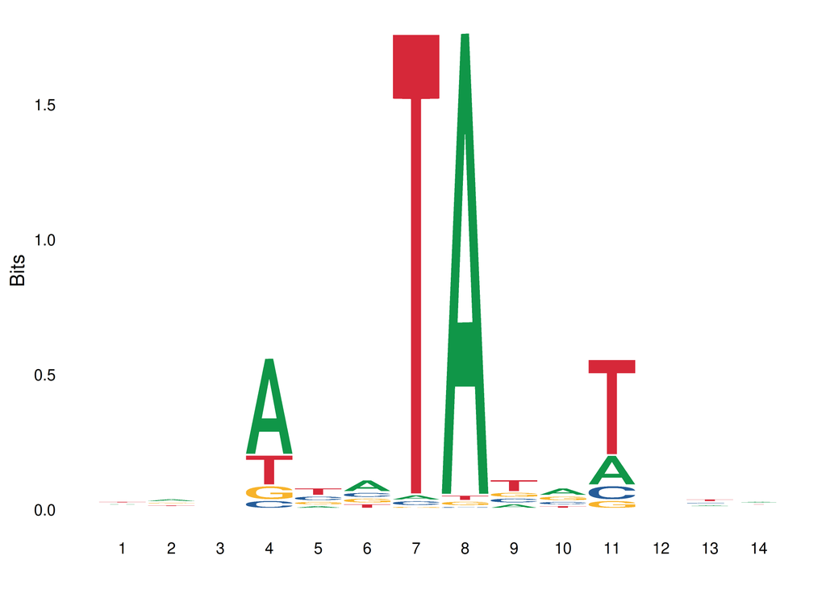

```r
seqs_for_logo = as.character(Biostrings::getSeq(BSgenome.Mmusculus.UCSC.mm10, surrounding_ints_gr))

#for some reason the ggseqlogo cannot handle 500,000 sequences, so I just subsample to 200,000
ggseqlogo(seqs_for_logo[!grepl("N", seqs_for_logo)])
```

Is this motif completely independent on how it was mapped?

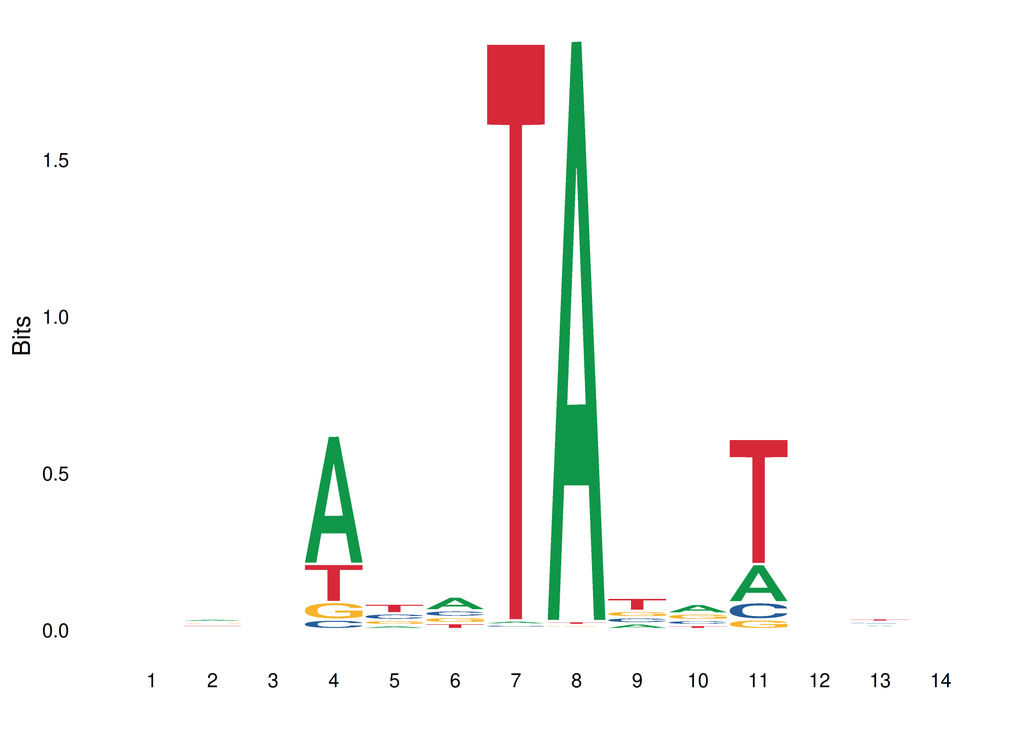

```r
tib_seq_by_map = SB_linked_tib %>%
  filter(strand != "*") %>%
  mutate(seq = seqs_for_logo)

ggseqlogo(filter(tib_seq_by_map, mapped_arms == "both_arms" & !grepl("N", seq))$seq)
```

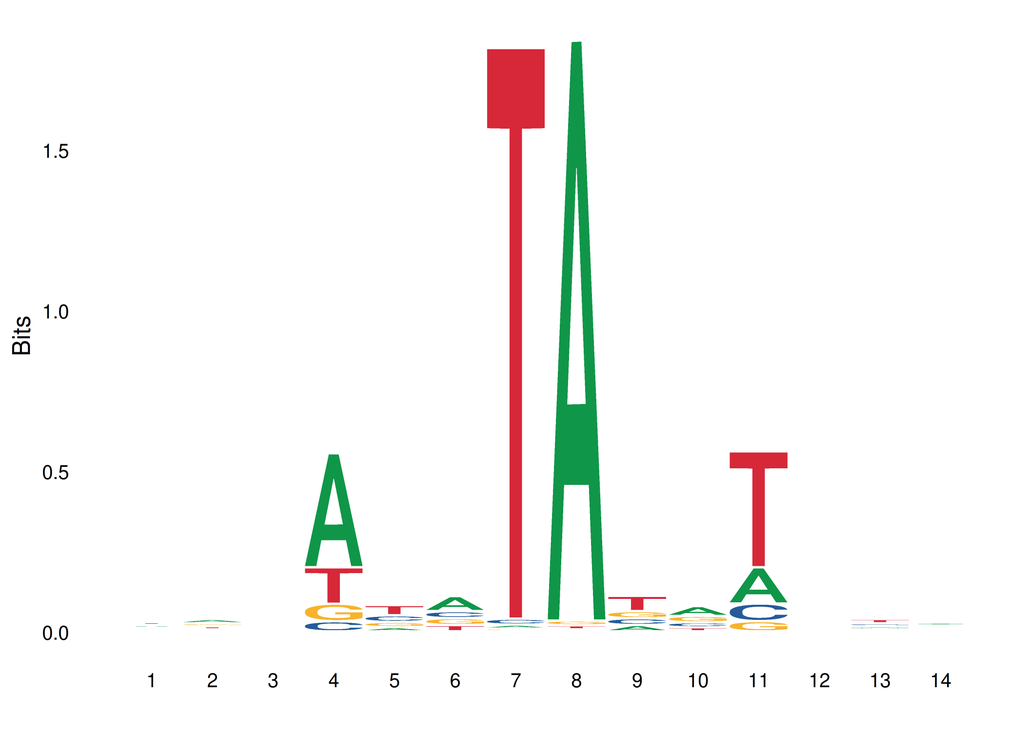

```r
ggseqlogo(filter(tib_seq_by_map, mapped_arms == "fw_only" & !grepl("N", seq))$seq) #right arm
```

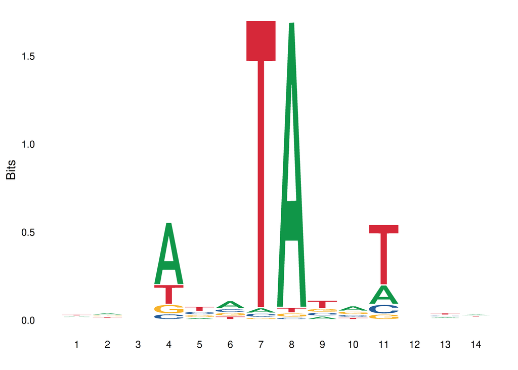

```r
ggseqlogo(filter(tib_seq_by_map, mapped_arms == "rv_only" & !grepl("N", seq))$seq) #left arm
```

In the logo we see a preference for an extra flanking A (upstream) and T (downstream). Do these specifically occur together, or is there just a preference for each separately? And how often do they really occur?

```r
seqs_tib = tibble(seq = seqs_for_logo) %>%
  mutate(ins_site = substr(seq, 7,8),
         left_flank = substr(seq,4,4),
         right_flank = substr(seq,11,11))%>%
  mutate(flanks = case_when(left_flank == "A" & right_flank == "T" ~ 'both',
                            left_flank == "A" & right_flank != "T" ~ 'left_only',
                            left_flank != "A" & right_flank == "T" ~ 'right_only',
                            .default = 'none'
                            ))

annots_logo = tibble(TA_site = TRUE,
  flanks = c("both", "left_only", "right_only", "none"),
                     motif = c("ANNTANNT",
                               "ANNTANNV",
                               "BNNTANNT",
                               "BNNTANNV"))

seqs_tib %>%
  mutate(TA_site = ins_site == "TA") %>%
  group_by(TA_site, flanks) %>%
  summarize(N = n()) %>%
  left_join(annots_logo) %>%
  group_by(TA_site)%>%
  mutate(fract = N / sum(N))
```

```
## # A tibble: 8 × 5
## # Groups:   TA_site [2]
##   TA_site flanks          N motif     fract
##   <lgl>   <chr>       <int> <chr>     <dbl>
## 1 FALSE   both         3982 <NA>     0.168
## 2 FALSE   left_only    5912 <NA>     0.250
## 3 FALSE   none         8224 <NA>     0.348
## 4 FALSE   right_only   5531 <NA>     0.234
## 5 TRUE    both       187514 ANNTANNT 0.375
## 6 TRUE    left_only  139379 ANNTANNV 0.278
## 7 TRUE    none        34955 BNNTANNV 0.0698
## 8 TRUE    right_only 138794 BNNTANNT 0.277
```

```r
seqs_tib %>%
  mutate(TA_site = ins_site == "TA") %>%
  filter(TA_site)%>%
  group_by( flanks) %>%
  summarize(N = n()) %>%
  left_join(annots_logo) %>%
  mutate(fract = N / sum(N))
```

```
## # A tibble: 4 × 5
##   flanks          N TA_site motif     fract
##   <chr>       <int> <lgl>   <chr>     <dbl>
## 1 both       187514 TRUE    ANNTANNT 0.375
## 2 left_only  139379 TRUE    ANNTANNV 0.278
## 3 none        34955 TRUE    BNNTANNV 0.0698
## 4 right_only 138794 TRUE    BNNTANNT 0.277
```

Turn this into a table for only the integrations with TA, 4 possible motifs, give fractions

Is both as expected from left and right only?

```r
seqs_tib %>%
  filter(ins_site == "TA") %>%
  summarize(f_left = sum(left_flank == "A")/n(),
            f_right = sum(right_flank == "T")/n(),
            expect_both = f_left * f_right * n(),
            obs_both = sum(left_flank == "A" & right_flank == "T"))
```

```
## # A tibble: 1 × 4
##   f_left f_right expect_both obs_both
##    <dbl>   <dbl>       <dbl>    <int>
## 1  0.653   0.652     213062.   187514
```

So observed both is slightly less than expected.

Sequence logo when there is no TA

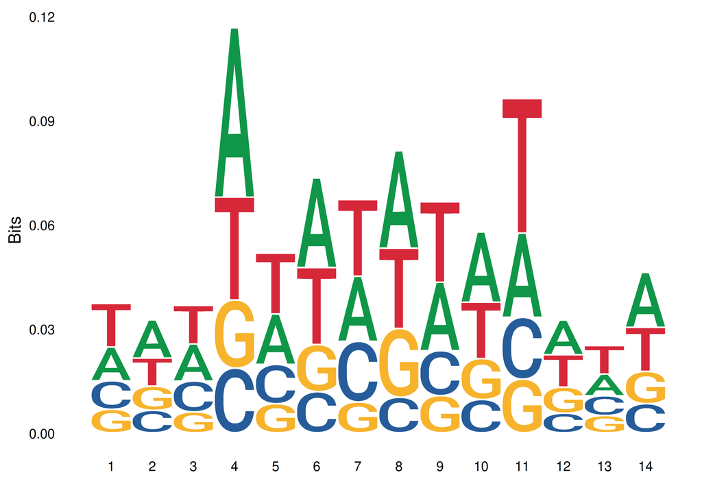

```r
seqs_no_TA = seqs_tib %>%
  filter(ins_site != "TA") %>%
  filter(!grepl("N", seq)) %>%
  pull(seq)

ggseqlogo(seqs_no_TA)
```

Confidence of integrations without a TA

```r
tib_seq_by_map %>%
  mutate(ins_site = substr(seq, 7,8),
         TA_site = ins_site == "TA") %>%
  group_by(TA_site) %>%
  summarize(av_read_count = mean(read_count),
            av_read_count_1 = mean(read_count_1),
            av_read_count_2 = mean(read_count_2),
            av_mapq= mean(mapq))
```

```
## # A tibble: 2 × 5
##   TA_site av_read_count av_read_count_1 av_read_count_2 av_mapq
##   <lgl>           <dbl>           <dbl>           <dbl>   <dbl>
## 1 FALSE            1.22           0.389           0.828    32.9
## 2 TRUE             1.33           0.607           0.722    38.6
```

```r
tib_seq_by_map %>%
  mutate(ins_site = substr(seq, 7,8),
         TA_site = ins_site == "TA") %>%
  group_by(ins_site) %>%
  summarize(av_read_count = mean(read_count),
            av_read_count_1 = mean(read_count_1),
            av_read_count_2 = mean(read_count_2),
            av_mapq= mean(mapq),
            N = n())
```

```
## # A tibble: 17 × 6
##    ins_site av_read_count av_read_count_1 av_read_count_2 av_mapq      N
##    <chr>            <dbl>           <dbl>           <dbl>   <dbl>  <int>
##  1 AA                1.21           0.463           0.747    32.0   1929
##  2 AC                1.21           0.228           0.982    33.7    912
##  3 AG                1.21           0.222           0.984    33.5    974
##  4 AT                1.22           0.268           0.952    34.5   2792
##  5 CA                1.26           0.501           0.755    33.2   4747
##  6 CC                1.14           0.313           0.830    31.8    342
##  7 CG                1.36           0.270           1.09     29.8    115
##  8 CT                1.18           0.260           0.924    33.3    942
##  9 GA                1.17           0.522           0.649    31.7   1495
## 10 GC                1.14           0.220           0.915    31.6    295
## 11 GG                1.12           0.199           0.917    30.7    351
## 12 GT                1.20           0.302           0.903    33.3    986
## 13 NN                1              0               1        42        1
## 14 TA                1.33           0.607           0.722    38.6 500642
## 15 TC                1.16           0.375           0.785    31.6   1429
## 16 TG                1.24           0.437           0.803    33.1   4329
## 17 TT                1.21           0.368           0.846    31.7   2010
```

Non-TA sites are supported by slightly fewer reads and slightly lower mapping quality, but it does not look worrisome. I think most of these integrations are still real integrations.

## frequency of motif in the mouse genome

I want to count how often each motif around TA occurs in the mouse genome. There is a problem that a single TA can be assigned to multiple windows of the motif, so instead of searching for the different motifs: take all TA sites (actually take a random sample of 10 milion) in the genome and classify them:

```r
all_TA_sites <- vmatchPattern("TA", BSgenome.Mmusculus.UCSC.mm10)

all_TA_sites_std <-  keepStandardChromosomes(all_TA_sites, pruning.mode = 'coarse')
length(all_TA_sites_std)
```

```
## [1] 337581652
```

```r
#subsample 10 million TA sites
set.seed(20260409)
sample_TA_sites  = sample(all_TA_sites_std[strand(all_TA_sites_std) =="+" & seqnames(all_TA_sites_std) != "chrM"], #count each TA once & remove M chromosome
                          10E6, replace =F)

# Keep only TA with full ±3 context (avoid chromosome edges)
valid <- start(sample_TA_sites) > 3 & end(sample_TA_sites) <= seqlengths(BSgenome.Mmusculus.UCSC.mm10)[as.character(seqnames(sample_TA_sites))] - 3

sample_TA_sites <- sample_TA_sites[valid]

# Get sequences
contexts_TA <- getSeq(
  BSgenome.Mmusculus.UCSC.mm10,
  names = seqnames(sample_TA_sites),
  start = start(sample_TA_sites) - 3,
  end   = end(sample_TA_sites) + 3
)

# Classify surrounding sequences
ctx_char <- as.character(contexts_TA)
left_base  <- substr(ctx_char, 1, 1)
right_base <- substr(ctx_char, 8, 8)

category <- character(length(ctx_char))
category[left_base != "A" & right_base != "T"] <- "BNNTANNV"
category[left_base != "A" & right_base == "T"] <- "BNNTANNT"
category[left_base == "A" & right_base != "T"] <- "ANNTANNV"
category[left_base == "A" & right_base == "T"] <- "ANNTANNT"

table(category)
```

```
## category
## ANNTANNT ANNTANNV BNNTANNT BNNTANNV
##  1119225  2166780  2169361  4544634
```

```r
sum(category== "ANNTANNT")/length(category)
```

```
## [1] 0.1119225
```

```r
sum(category== "ANNTANNV")/length(category)
```

```
## [1] 0.216678
```

```r
sum(category== "BNNTANNT")/length(category)
```

```
## [1] 0.2169361
```

```r
sum(category== "BNNTANNV")/length(category)
```

```
## [1] 0.4544634
```